# Random Forest Parameter Tuning - Machine Learning

Elisabeth Gangwer

24 November 2024

Lets first load a few packages which we will use for this analysis:

```r
#install.packages("randomForest")
#install.packages("caret")
library(randomForest)
library(caret)
library(xgboost)
library(xgboostExplainer)
library(pROC)
```

## Random Forests

The random forest algorithm works by building bootstrapped trees using only a selection of variables to split the data at each node.

The tuning parameters we can use for random forests are:

- Number of trees - The number of trees we build in the model
- mtry - The number of variables tried at each split in the model
- nodesize - The minimum size of the terminal nodes (Default 5)

Some other parameters that can affect the model are:

- sampsize - The sizes of the bootstrap sample to take (Can be used for imbalanced data by specifying the number of samples from each class to use.)
- maxnodes - The maximum number of terminal nodes in the model (This is generally controlled for using the nodesize parameter)
- replace - Should the sampled datasets used for each tree be taken with replacement for the data.(Answer for this is yes unless only using a subsample of the data)

In general random forests will not overfit our data. Therefore we can build a large number of trees and focus on tuning the mtry and node size parameters. Which will allow us to visualize the parameter combinations and how they perform.

## TOR Data

For this analysis we are going to be analyzing internet connections to predict if they come from the dark web.

Darknet is the unused address space of the internet which is not speculated to interact with other computers in the world. Any communication from the dark space is considered skeptical owing to its passive listening nature which accepts incoming packets, but outgoing packets are not supported. Due to the absence of legitimate hosts in the darknet, any traffic is contemplated to be unsought and is characteristically treated as probe, backscatter, or misconfiguration. Darknets are also known as network telescopes, sinkholes, or blackholes.

To access the Darknet or Darkweb people will generally use the TOR browser:

“Back in the mid-’90s, when the US Navy was looking into ways to securely communicate sensitive intelligence information, a mathematician and two computer scientists emerged from the Naval Research Lab with something called”onion routing.” It was a new kind of technology that would protect your internet traffic with layers of privacy. By 2003, The Onion Routing project, acronymed Tor, was in the hands of the public, where its vast network of users – the engine enabling Tor – has since continued to grow.

Today, thousands of volunteers all over the world are connecting their computers to the internet to create the Tor network by becoming “nodes” or “relays” for your internet traffic.

At a basic level, Tor is a type of internet-connected network with its own internet browser. Once you connect to the internet with the Tor browser, your internet traffic is stripped of its first layer of identifying information as it enters the Tor network, and is then sent bouncing through those relay nodes, which serve to encrypt and privatize your data, layer by layer – like an onion. Finally, your traffic hits an exit node and leaves the Tor network for the open web.

Once you’re in the Tor network, it’s nearly impossible for others to track your traffic’s manic pinballing path across the globe. And once you leave the Tor network via an exit node, the website you view (assuming it has HTTPS in front of its address) isn’t sure which part of the world you’re hailing from, offering you more privacy and protection.”

This data is stored as `tor_data.rda`. Lets load the data into the work space:

```r
load("tor_data.rda")
```

The data is already split into training and test sets using an 80/20 split called `train_db` and `test_db` respectively.

```r
summary(train_db)
```

```
##  Flow.Duration      Flow.Bytes.s       Flow.Packets.s      Flow.IAT.Mean
##  Min.   :      1   Min.   :        0   Min.   :      0.2   Min.   :      0
##  1st Qu.:  44305   1st Qu.:      105   1st Qu.:      4.9   1st Qu.:   9950
##  Median : 410823   Median :     1330   Median :     16.3   Median :  83224
##  Mean   :2974680   Mean   :   264002   Mean   :   3367.5   Mean   : 314766
##  3rd Qu.:7214797   3rd Qu.:    21907   3rd Qu.:    100.7   3rd Qu.: 410591
##  Max.   :9999999   Max.   :600000000   Max.   :3000000.0   Max.   :9987113
##   Flow.IAT.Std      Flow.IAT.Max      Flow.IAT.Min      Fwd.IAT.Mean
##  Min.   :      0   Min.   :      1   Min.   :  -2255   Min.   :      0
##  1st Qu.:      0   1st Qu.:  29453   1st Qu.:     26   1st Qu.:      0
##  Median :      0   Median : 179044   Median :   1389   Median :  19967
##  Mean   : 218993   Mean   : 892583   Mean   : 192835   Mean   : 348509
##  3rd Qu.:  56949   3rd Qu.: 452397   3rd Qu.: 207957   3rd Qu.: 411216
##  Max.   :7045167   Max.   :9996903   Max.   :9987113   Max.   :9997140
##   Fwd.IAT.Std       Fwd.IAT.Max       Fwd.IAT.Min       Bwd.IAT.Mean
##  Min.   :      0   Min.   :      0   Min.   :   -186   Min.   :      0
##  1st Qu.:      0   1st Qu.:      0   1st Qu.:      0   1st Qu.:      0
##  Median :      0   Median :  99606   Median :     33   Median :      0
##  Mean   : 228953   Mean   : 864449   Mean   : 209967   Mean   : 118713
##  3rd Qu.:  29856   3rd Qu.: 436445   3rd Qu.: 203846   3rd Qu.:  17555
##  Max.   :7065086   Max.   :9997140   Max.   :9997140   Max.   :9996903
##   Bwd.IAT.Std       Bwd.IAT.Max       Bwd.IAT.Min       Active.Mean
##  Min.   :      0   Min.   :      0   Min.   :   -292   Min.   :      0
##  1st Qu.:      0   1st Qu.:      0   1st Qu.:      0   1st Qu.:      0
##  Median :      0   Median :      0   Median :      0   Median :      0
##  Mean   : 118708   Mean   : 472191   Mean   :  50658   Mean   :  38598
##  3rd Qu.:   9419   3rd Qu.:  82438   3rd Qu.:     17   3rd Qu.:      0
##  Max.   :7053719   Max.   :9996903   Max.   :9996903   Max.   :4999863
##    Active.Std   Active.Max        Active.Min        Idle.Mean          Idle.Std
##  Min.   :0    Min.   :      0   Min.   :      0   Min.   :      0   Min.   :0
##  1st Qu.:0    1st Qu.:      0   1st Qu.:      0   1st Qu.:      0   1st Qu.:0
##  Median :0    Median :      0   Median :      0   Median :      0   Median :0
##  Mean   :0    Mean   :  38598   Mean   :  38598   Mean   : 304459   Mean   :0
##  3rd Qu.:0    3rd Qu.:      0   3rd Qu.:      0   3rd Qu.:      0   3rd Qu.:0
##  Max.   :0    Max.   :4999863   Max.   :4999863   Max.   :9996903   Max.   :0
##     Idle.Max          Idle.Min          label
##  Min.   :      0   Min.   :      0   nonTOR:47828
##  1st Qu.:      0   1st Qu.:      0   TOR   : 6436
##  Median :      0   Median :      0
##  Mean   : 304459   Mean   : 304459
##  3rd Qu.:      0   3rd Qu.:      0
##  Max.   :9996903   Max.   :9996903
```

We see we have 24 variables for our analysis. These variables relate to the network connection made between the source and destination. The way internet traffic works is that data is broken up into packets and sent from the source to the destination which then sends packets back to the source. A flow becomes inactive after no packets have been observed for a period of time, this value is usually 15 seconds. The variables we have are:

- Flow.Duration - A flow refers to any connection or connection-like communication channel. The duration measures the length of time between the first and last packets sent.
- Flow.Bytes.s - Number of bytes sent in the connection
- Flow.Packets.s - Number of packets sent in the communication
- Flow.IAT.Mean - Packets flow inter arrival time Mean
- Flow.IAT.Std - Packets flow inter arrival time Standard deviation
- Flow.IAT.Max - Packets flow inter arrival time Max.
- Flow.IAT.Min - Packets flow inter arrival time Min
- Fwd.IAT.Mean - Forward inter arrival time, the time between two packets Sent forward direction Mean
- Fwd.IAT.Std - Forward inter arrival time, the time between two packets sent forward direction Standard deviation.
- Fwd.IAT.Max - Forward inter arrival time, the time between two packets sent forward direction Max
- Fwd.IAT.Min - Forward inter arrival time, the time between two packets sent forward direction Min.
- Bwd.IAT.Mean -Backward inter arrival time, the time between two packets sent backward Mean.
- Bwd.IAT.Std - Backward inter arrival time, the time between two packets sent backward Standard deviation.
- Bwd.IAT.Max - Backward inter arrival time, the time between two packets sent backward Max.
- Bwd.IAT.Min - Backward inter arrival time, the time between two packets sent backward Min
- Active.Mean - The amount of time a flow was active before becoming idle mean.
- Active.Std - The amount of time a flow was active before becoming idle Standard deviation
- Active.Max - The amount of time a flow was active before becoming idle Max.
- Active.Min - The amount of time a flow was active before becoming idle Min.
- Idle.Mean - The amount of time a flow was idle before becoming active Mean
- Idle.Std - The amount of time a flow was idle before becoming active Std deviation.
- Idle.Max - The amount of time a flow was idle before becoming active Max.
- Idle.Min - The amount of time a flow was idle before becoming active Min.
- label - Either TOR indicating a TOR connection or nonTOR indication a non-TOR connection

We will use the label as a response variable and the other variables as explanatory variables.

# Best Random Forest

```r
rf_mod <- randomForest(label ~., # Set tree formula
                         data = train_db, # Set dataset
                         ntree = 200,
                         nodesize = 1,
                         mtry = 12) # Set number of trees to use
rf_preds <- predict(rf_mod, test_db, type = "prob") # Create predictions for random forest model

# Convert predictions to classes, using 0.5
rf_pred_class <- rep("nonTOR", nrow(rf_preds))
rf_pred_class[rf_preds[,2] >= 0.5] <- "TOR"

t <- table(rf_pred_class, test_db$label) # Create table
confusionMatrix(t, positive = "TOR") # Produce confusion matrix
```

```
## Confusion Matrix and Statistics
##
##
## rf_pred_class nonTOR   TOR
##        nonTOR  11894    91
##        TOR        62  1517
##
##                Accuracy : 0.9887
##                  95% CI : (0.9868, 0.9904)
##     No Information Rate : 0.8815
##     P-Value [Acc > NIR] : < 2e-16
##
##                   Kappa : 0.9456
##
##  Mcnemar's Test P-Value : 0.02359
##
##             Sensitivity : 0.9434
##             Specificity : 0.9948
##          Pos Pred Value : 0.9607
##          Neg Pred Value : 0.9924
##              Prevalence : 0.1185
##          Detection Rate : 0.1118
##    Detection Prevalence : 0.1164
##       Balanced Accuracy : 0.9691
##
##        'Positive' Class : TOR
##
```

## Assignment - 20 Total Marks

- Apply a bagging model to the DarkNet dataset (2 marks)

```r
set.seed(258506) # Set random number generator seed for reproducability

bag_mod <- randomForest(label ~., # Set tree formula
                data = train_db, # Set dataset
                mtry = 23, # Set mtry to number of variables
                ntree = 200) # Set number of trees to use
bag_mod
```

```
##
## Call:
##  randomForest(formula = label ~ ., data = train_db, mtry = 23,      ntree = 200)
##                Type of random forest: classification
##                      Number of trees: 200
## No. of variables tried at each split: 23
##
##         OOB estimate of  error rate: 1.14%
## Confusion matrix:
##        nonTOR  TOR class.error
## nonTOR  47542  286 0.005979761
## TOR       334 6102 0.051895587
```

```r
# Predicting with Bagging Model
bag_preds <- predict(bag_mod, test_db, type = 'prob')
bag_preds_class <- rep("nonTOR", nrow(rf_preds))
bag_preds_class[rf_preds[,2] >= 0.5] <- "TOR"
```

- Apply an XGBoost model to the DarkNet dataset (2 marks)

```r
dtrain <- xgb.DMatrix(data = as.matrix(train_db[, 1:23]), label = as.numeric(train_db$label) -1)
dtest <- xgb.DMatrix(data = as.matrix(test_db[, 1:23]), label = as.numeric(test_db$label) - 1)

set.seed(111111)
bst_1 <- xgboost(data = dtrain, # Set training data
               nrounds = 1000,
               early_stopping_rounds = 50,
               verbose = 1, # 1 - Prints out fit
               print_every_n = 50, # Prints out result every 50th iteration
               objective = "binary:logistic", # Set objective
               eval_metric = "auc",
               eval_metric = "error") # Set evaluation metric to use
```

```
## Multiple eval metrics are present. Will use train_error for early stopping.
## Will train until train_error hasn't improved in 50 rounds.
##
## Stopping. Best iteration:
```

- Visualize and decide the optimal number of iterations for XGBoost.(Plot the error curve against the number of iterations) (2 marks)

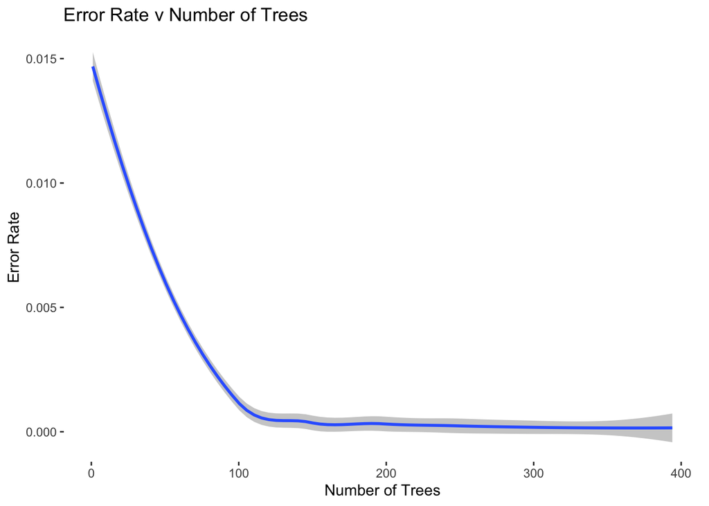

```r
plot_data<- bst_1$evaluation_log

g_1 <- ggplot(plot_data, aes(x = iter, y = train_error))+
  geom_smooth(alpha = 0.5) +
  theme_bw() + # Set theme
  theme(panel.grid.major = element_blank(), # Remove grid
        panel.grid.minor = element_blank(), # Remove grid
        panel.border = element_blank(), # Remove grid
        panel.background = element_blank()) + # Remove grid
  labs(x = "Number of Trees", title = "Error Rate v Number of Trees",
       y = "Error Rate")  # Set labels
g_1
```

The error rate stabilizes a little before the 200th tree, will go with 200 iterations to tune the eta parameter.

- Tune the eta parameter for XGboost (2 marks)

```r
# Try an eta of 0.1 first
set.seed(111111)
bst_2 <- xgb.cv(data = dtrain, # Set training data

              nfold = 5, # Use 5 fold cross-validation

               eta = 0.1, # Set learning rate

               nrounds = 200, # Set number of rounds
               early_stopping_rounds = 50,
               verbose = 1, # 1 - Prints out fit
               nthread = 1, # Set number of parallel threads
               print_every_n = 20, # Prints out result every 20th iteration

               objective = "binary:logistic", # Set objective
               eval_metric = "auc",
               eval_metric = "error") # Set evaluation metric to use
```

```
## Multiple eval metrics are present. Will use test_error for early stopping.
## Will train until test_error hasn't improved in 50 rounds.
##
```

```r
set.seed(111111)
bst_3 <- xgb.cv(data = dtrain,
                nfold = 5,

                eta = 0.01, #try 0.01

                nrounds = 200,
                early_stopping_rounds = 50,
                verbose = 1,
                nthread = 1,
                print_every_n = 20,

                objective = "binary:logistic",
                eval_metric = "auc",
                eval_metric = "error")
```

```
## Multiple eval metrics are present. Will use test_error for early stopping.
## Will train until test_error hasn't improved in 50 rounds.
##
```

```r
set.seed(111111)
bst_4 <- xgb.cv(data = dtrain,
                nfold = 5,

                eta = 0.05, #try 0.05

                nrounds = 200,
                early_stopping_rounds = 50,
                verbose = 1,
                nthread = 1,
                print_every_n = 20,
                objective = "binary:logistic",
                eval_metric = "auc",
                eval_metric = "error")
```

```
## Multiple eval metrics are present. Will use test_error for early stopping.
## Will train until test_error hasn't improved in 50 rounds.
##
```

```r
set.seed(111111)
bst_5 <- xgb.cv(data = dtrain,
                nfold = 5,

                eta = 0.15, #try 0.15

                nrounds = 200,
                early_stopping_rounds = 50,
                verbose = 1,
                nthread = 1,
                print_every_n = 20,
                objective = "binary:logistic",
                eval_metric = "auc",
                eval_metric = "error")
```

```
## Multiple eval metrics are present. Will use test_error for early stopping.
## Will train until test_error hasn't improved in 50 rounds.
##
```

```r
set.seed(111111)
bst_6 <- xgb.cv(data = dtrain,
                nfold = 5,

                eta = 0.20, #try 0.20

                nrounds = 200,
                early_stopping_rounds = 50,
                verbose = 1,
                nthread = 1,
                print_every_n = 20,
                objective = "binary:logistic",
                eval_metric = "auc",
                eval_metric = "error")
```

```
## Multiple eval metrics are present. Will use test_error for early stopping.
## Will train until test_error hasn't improved in 50 rounds.
##
```

```r
set.seed(111111)
bst_7 <- xgb.cv(data = dtrain,
                nfold = 5,

                eta = 0.3, #try 0.3

                nrounds = 200,
                early_stopping_rounds = 50,
                verbose = 1,
                nthread = 1,
                print_every_n = 20,
                objective = "binary:logistic",
                eval_metric = "auc",
                eval_metric = "error")
```

```
## Multiple eval metrics are present. Will use test_error for early stopping.
## Will train until test_error hasn't improved in 50 rounds.
##
```

```r
set.seed(111111)
bst_8 <- xgb.cv(data = dtrain,
                nfold = 5,

                eta = 0.25, #try 0.25

                nrounds = 200,
                early_stopping_rounds = 50,
                verbose = 1,
                nthread = 1,
                print_every_n = 20,
                objective = "binary:logistic",
                eval_metric = "auc",
                eval_metric = "error")
```

```
## Multiple eval metrics are present. Will use test_error for early stopping.
## Will train until test_error hasn't improved in 50 rounds.
##
```

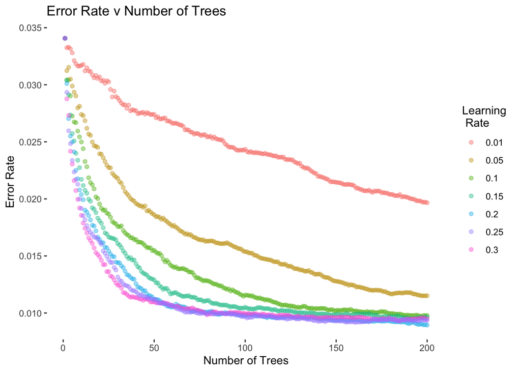

```r
# Extract results for model with eta = 0.1
pd2 <- cbind.data.frame(bst_2$evaluation_log[,c("iter", "test_error_mean")], rep(0.1, nrow(bst_2$evaluation_log)))
names(pd2)[3] <- "eta"
# Extract results for model with eta = 0.01
pd3 <- cbind.data.frame(bst_3$evaluation_log[,c("iter", "test_error_mean")], rep(0.01, nrow(bst_3$evaluation_log)))
names(pd3)[3] <- "eta"
# Extract results for model with eta = 0.05
pd4 <- cbind.data.frame(bst_4$evaluation_log[,c("iter", "test_error_mean")], rep(0.05, nrow(bst_4$evaluation_log)))
names(pd4)[3] <- "eta"
# Extract results for model with eta = 0.15
pd5 <- cbind.data.frame(bst_5$evaluation_log[,c("iter", "test_error_mean")], rep(0.15, nrow(bst_5$evaluation_log)))
names(pd5)[3] <- "eta"
# Extract results for model with eta = 0.20
pd6 <- cbind.data.frame(bst_6$evaluation_log[,c("iter", "test_error_mean")], rep(0.2, nrow(bst_6$evaluation_log)))
names(pd6)[3] <- "eta"
# Extract results for model with eta = 0.3
pd7 <- cbind.data.frame(bst_7$evaluation_log[,c("iter", "test_error_mean")], rep(0.3, nrow(bst_7$evaluation_log)))
names(pd7)[3] <- "eta"
# Extract results for model with eta = 0.25
pd8 <- cbind.data.frame(bst_8$evaluation_log[,c("iter", "test_error_mean")], rep(0.25, nrow(bst_8$evaluation_log)))
names(pd8)[3] <- "eta"
# Join datasets
plot_data <- rbind.data.frame(pd2, pd3, pd4, pd5, pd6, pd7, pd8)
# Converty ETA to factor
plot_data$eta <- as.factor(plot_data$eta)
# Plot points
g_3 <- ggplot(plot_data, aes(x = iter, y = test_error_mean, color = eta))+
  geom_point(alpha = 0.4) +
  theme_bw() + # Set theme
  theme(panel.grid.major = element_blank(), # Remove grid
        panel.grid.minor = element_blank(), # Remove grid
        panel.border = element_blank(), # Remove grid
        panel.background = element_blank()) + # Remove grid
  labs(x = "Number of Trees", title = "Error Rate v Number of Trees",
       y = "Error Rate", color = "Learning \n Rate")  # Set labels
g_3
```

```r
bst_best <- xgboost(data = dtrain,
                    eta = 0.25, # Set the learning rate to 0.25
                    nrounds = 200,
                    early_stopping_rounds = 20,
                    verbose = 1,
                    print_every_n = 20,
                    objective = "binary:logistic",
                    eval_metric = "auc",
                    eval_metric = "error")
```

```
## Multiple eval metrics are present. Will use train_error for early stopping.
## Will train until train_error hasn't improved in 20 rounds.
##
## Stopping. Best iteration:
```

```r
boost_preds_best <- predict(bst_best, dtest)
pred_dat <- cbind.data.frame(boost_preds_best , test_db$label)
boost_pred_class_best <- rep('nonTOR', length(boost_preds_best))
boost_pred_class_best[boost_preds_best >= 0.5] <- 'TOR'
```

- Extract and plot the variable importance for XGBoost (1 mark)

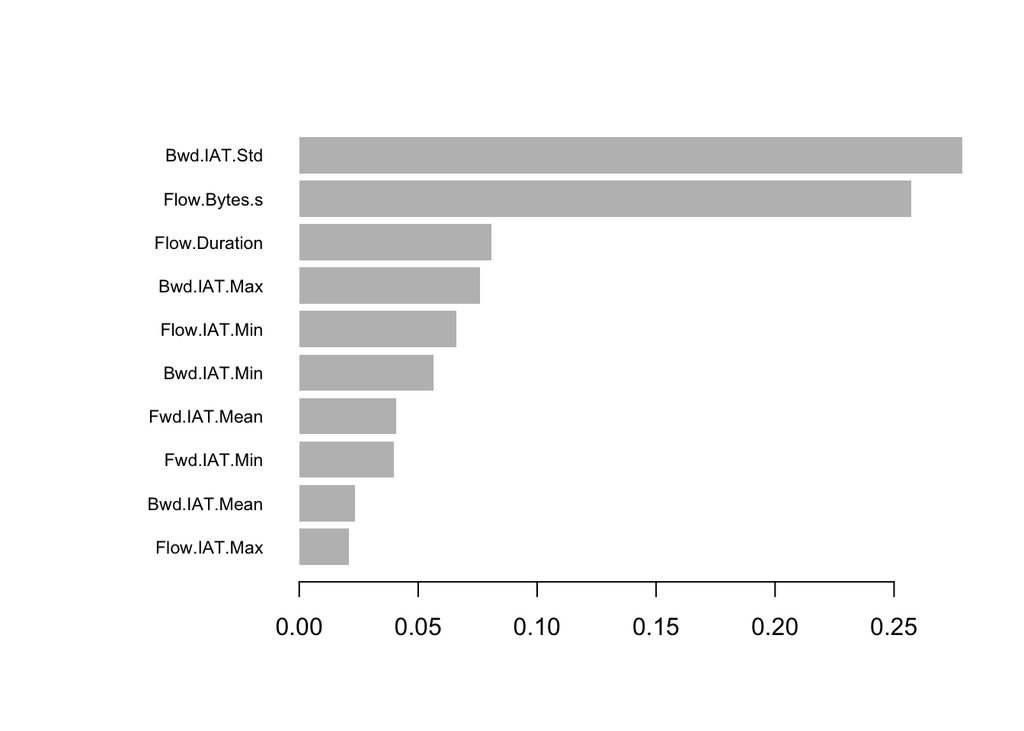

```r
imp_mat <- xgb.importance(model = bst_best)
xgb.plot.importance(imp_mat, top_n = 10)
```

- Which features were most important for the XGBoost model? (1 mark)  
  The 10 most important features for the XGBoost model is Bwd.IAT.Std, Flow.Bytes.s, Flow.Duration, Bwd.IAT.Max, Flow.IAT.Min, Bwd.IAT.Min, Fwd.IAT.Mean, Fwd.IAT.Min, Bwd.IAT.Mean, and Flow.IAT.Max.
- Compare the three models (Last random forest from pre-assignment, bagging, XGBoost) using an ROC plot. (2 marks)

```r
# Random Forest Model
rf_preds_tor <- rf_preds[, "TOR"]
roc1 = roc(test_db$label, rf_preds_tor)
# Bagging Model
bag_preds_tor <- bag_preds[, "TOR"]
roc2 = roc(test_db$label, bag_preds_tor)
# XGBoost Model
roc3 = roc(test_db$label, boost_preds_best)
```

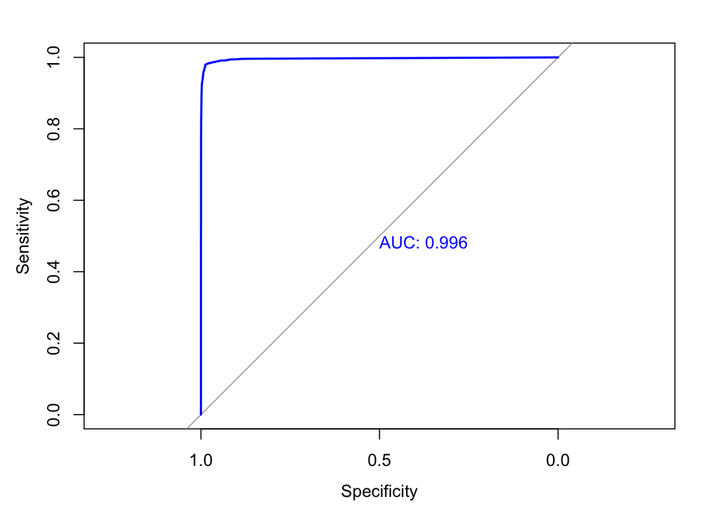

```r
plot.roc(roc1, print.auc = TRUE, col = 'blue', print.auc.col = 'blue')
```

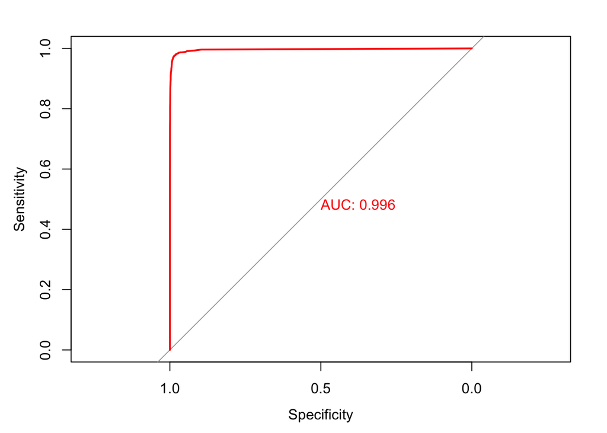

```r
plot.roc(roc2, print.auc = TRUE, col = 'red', print.auc.col = 'red')
```

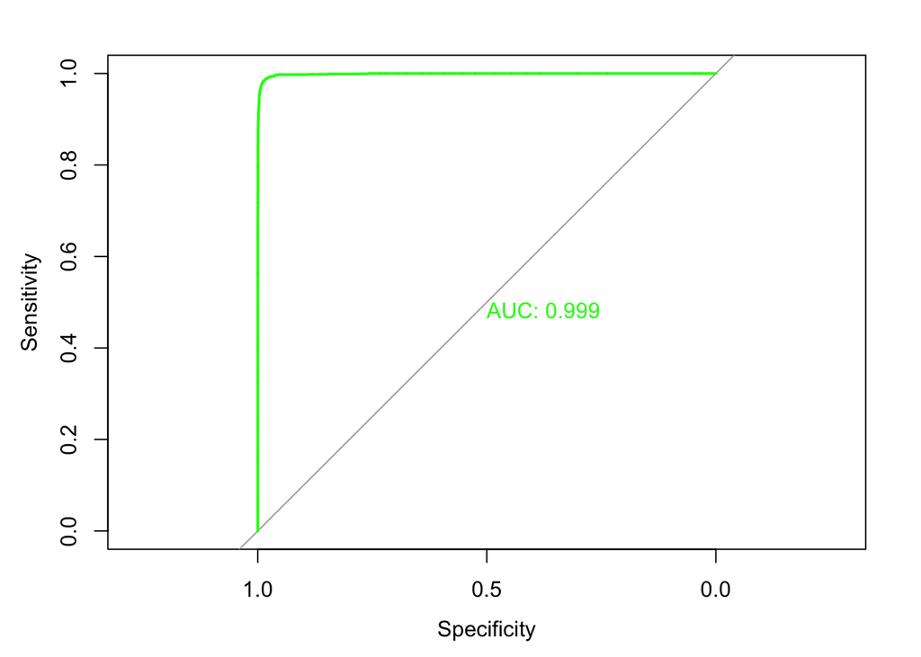

```r
plot.roc(roc3, print.auc = TRUE, col = 'green', print.auc.col = 'green')
```

- Which of the three models (random forest, bagging, XGBoost) gave the best results? (1 mark)  
  According to the AUC, the XGBoost model gave the best result with an AUC of 0.999.
- Can you beat a sensitivity score of 0.96 while keeping overall accuracy above 0.98 and the cut-off set as 0.5? (4 marks - Partial Credit for Attempt)

```r
# Tune the max depth and min child values
max_depth_vals <- c(3, 5, 7, 10, 15) # Create vector of max depth values
min_child_weight <- c(1,3,5,7, 10, 15) # Create vector of min child values

# Expand grid of parameter values
cv_params <- expand.grid(max_depth_vals, min_child_weight)
names(cv_params) <- c("max_depth", "min_child_weight")
# Create results vector
auc_vec <- error_vec <- rep(NA, nrow(cv_params))
# Loop through results
for(i in 1:nrow(cv_params)){
  set.seed(111111)
  bst_tune <- xgb.cv(data = dtrain, # Set training data

              nfold = 5, # Use 5 fold cross-validation

              eta = 0.25, # Set learning rate
              max.depth = cv_params$max_depth[i], # Set max depth
              min_child_weight = cv_params$min_child_weight[i], # Set minimum number of samples in node to split


              nrounds = 200, # Set number of rounds
              early_stopping_rounds = 20, # Set number of rounds to stop at if there is no improvement

              verbose = 1, # 1 - Prints out fit
              nthread = 1, # Set number of parallel threads
              print_every_n = 20, # Prints out result every 20th iteration

              objective = "binary:logistic", # Set objective
              eval_metric = "auc", # Set evaluation metric to use
              eval_metric = "error") # Set evaluation metric to use
  auc_vec[i] <- bst_tune$evaluation_log$test_auc_mean[bst_tune$best_ntreelimit]
  error_vec[i] <- bst_tune$evaluation_log$test_error_mean[bst_tune$best_ntreelimit]

}
```

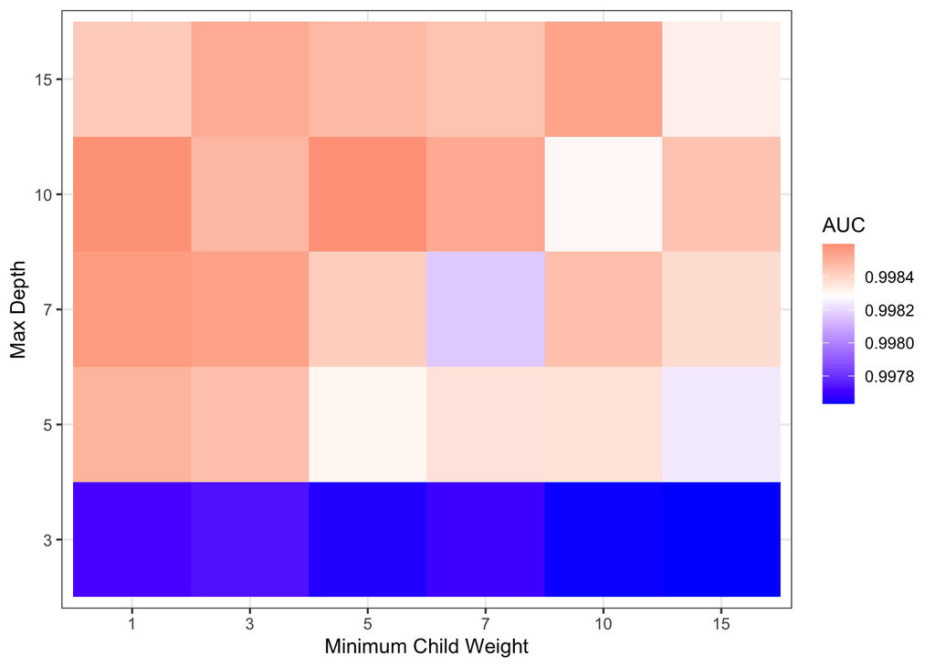

```r
# Graph the results to find the max_depth and min_child_weight
res_db <- cbind.data.frame(cv_params, auc_vec, error_vec)
names(res_db)[3:4] <- c("auc", "error")
res_db$max_depth <- as.factor(res_db$max_depth) # Convert tree number to factor for plotting
res_db$min_child_weight <- as.factor(res_db$min_child_weight) # Convert node size to factor for plotting
# Print AUC heatmap
g_5 <- ggplot(res_db, aes(y = max_depth, x = min_child_weight, fill = auc)) + # set aesthetics
  geom_tile() + # Use geom_tile for heatmap
  theme_bw() + # Set theme
  scale_fill_gradient2(low = "blue", # Choose low color
    mid = "white", # Choose mid color
    high = "red", # Choose high color
    midpoint =mean(res_db$auc), # Choose mid point
    space = "Lab",
    na.value ="grey", # Choose NA value
    guide = "colourbar", # Set color bar
    aesthetics = "fill") + # Select aesthetics to apply
  labs(x = "Minimum Child Weight", y = "Max Depth", fill = "AUC") # Set labels
g_5
```

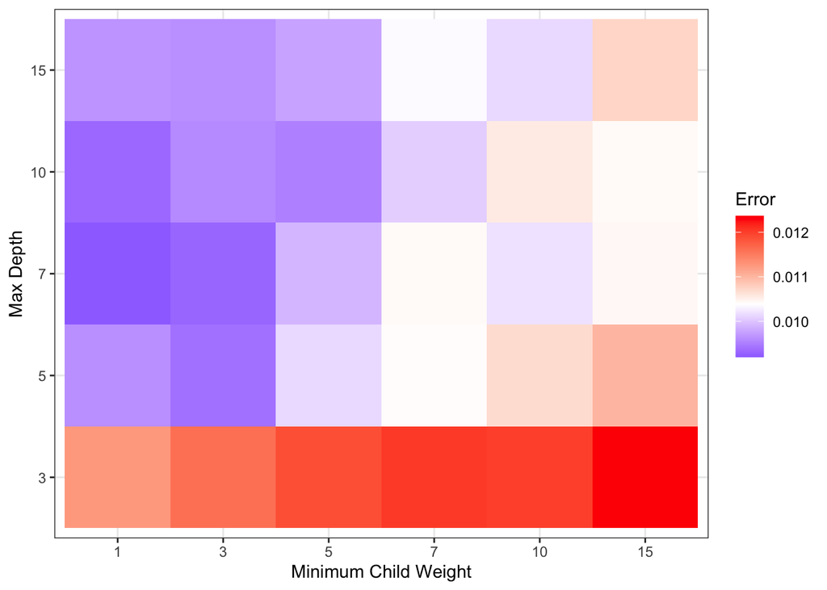

```r
g_6 <- ggplot(res_db, aes(y = max_depth, x = min_child_weight, fill = error)) + # set aesthetics
  geom_tile() + # Use geom_tile for heatmap
  theme_bw() + # Set theme
  scale_fill_gradient2(low = "blue", # Choose low color
    mid = "white", # Choose mid color
    high = "red", # Choose high color
    midpoint =mean(res_db$error), # Choose mid point
    space = "Lab",
    na.value ="grey", # Choose NA value
    guide = "colourbar", # Set color bar
    aesthetics = "fill") + # Select aesthetics to apply
  labs(x = "Minimum Child Weight", y = "Max Depth", fill = "Error") # Set labels
g_6 # Generate plot
```

```r
# min-child weight - 5 and Max Depth 10
```

```r
# Tune the gamma
gamma_vals <- c(0, 0.05, 0.1, 0.15, 0.2) # Create vector of gamma values

# Be Careful - This can take a very long time to run
set.seed(111111)
auc_vec <- error_vec <- rep(NA, length(gamma_vals))
for(i in 1:length(gamma_vals)){
  bst_tune <- xgb.cv(data = dtrain, # Set training data

              nfold = 5, # Use 5 fold cross-validation

              eta = 0.25, # Set learning rate
              max.depth = 10, # Set max depth
              min_child_weight = 5, # Set minimum number of samples in node to split
              gamma = gamma_vals[i], # Set minimum loss reduction for split



              nrounds = 200, # Set number of rounds
              early_stopping_rounds = 20, # Set number of rounds to stop at if there is no improvement

              verbose = 1, # 1 - Prints out fit
              nthread = 1, # Set number of parallel threads
              print_every_n = 20, # Prints out result every 20th iteration

              objective = "binary:logistic", # Set objective
              eval_metric = "auc", # Set evaluation metric to use
              eval_metric = "error") # Set evaluation metric to use
  auc_vec[i] <- bst_tune$evaluation_log$test_auc_mean[bst_tune$best_ntreelimit]
  error_vec[i] <- bst_tune$evaluation_log$test_error_mean[bst_tune$best_ntreelimit]

}
cbind.data.frame(gamma_vals, auc_vec, error_vec)
# Gamma value seems to have the highest AUC at 0.10, gamma value seems to have the lowest error at 0.00. Will use 0.10 due to the small difference between error value in 0.00 and 0.10.
```

[output not shown]

```r
# Re-calibrate the model
set.seed(111111)
bst <- xgb.cv(data = dtrain,

              nfold = 5,

              eta = 0.25,
              max.depth = 10,
              min_child_weight = 5,
              gamma = 0.1,


              nrounds = 1000,
              early_stopping_rounds = 50,

              verbose = 1,
              nthread = 1,
              print_every_n = 50,

              objective = "binary:logistic",
              eval_metric = "auc",
              eval_metric = "error")
```

```
## Multiple eval metrics are present. Will use test_error for early stopping.
## Will train until test_error hasn't improved in 50 rounds.
##
## Stopping. Best iteration:
```

```r
# Best iteration is at 230, will set nrounds to 250
```

```r
# Tune the subsample and colsample
subsample <- c(0.6, 0.7, 0.8, 0.9, 1) # Create vector of subsample values
colsample_by_tree <- c(0.6, 0.7, 0.8, 0.9, 1) # Create vector of col sample values

# Expand grid of tuning parameters
cv_params <- expand.grid(subsample, colsample_by_tree)
names(cv_params) <- c("subsample", "colsample_by_tree")
# Create vectors to store results
auc_vec <- error_vec <- rep(NA, nrow(cv_params))
# Loop through parameter values
for(i in 1:nrow(cv_params)){
  set.seed(111111)
  bst_tune <- xgb.cv(data = dtrain, # Set training data

              nfold = 5, # Use 5 fold cross-validation

              eta = 0.25, # Set learning rate
              max.depth = 10, # Set max depth
              min_child_weight = 5, # Set minimum number of samples in node to split
              gamma = 0.1, # Set minimum loss reduction for split
              subsample = cv_params$subsample[i], # Set proportion of training data to use in tree
              colsample_bytree = cv_params$colsample_by_tree[i], # Set number of variables to use in each tree

              nrounds = 250, # Set number of rounds
              early_stopping_rounds = 20, # Set number of rounds to stop at if there is no improvement

              verbose = 1, # 1 - Prints out fit
              nthread = 1, # Set number of parallel threads
              print_every_n = 20, # Prints out result every 20th iteration

              objective = "binary:logistic", # Set objective
              eval_metric = "auc", # Set evaluation metric to use
              eval_metric = "error") # Set evaluation metric to use
  auc_vec[i] <- bst_tune$evaluation_log$test_auc_mean[bst_tune$best_ntreelimit]
  error_vec[i] <- bst_tune$evaluation_log$test_error_mean[bst_tune$best_ntreelimit]

}
```

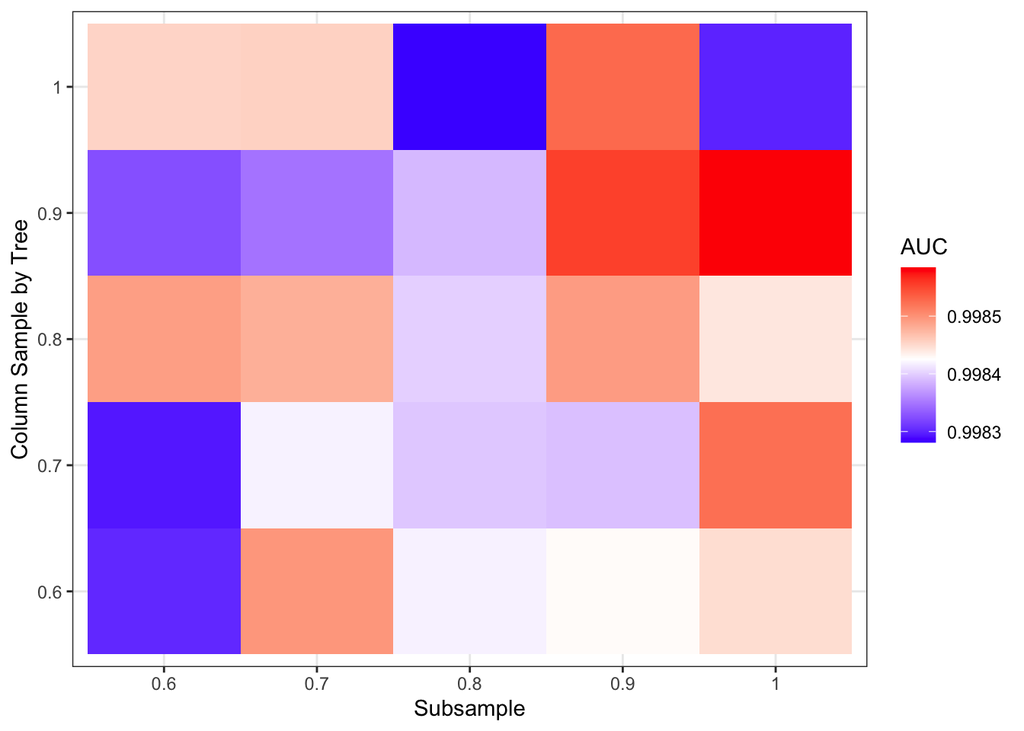

```r
# Graph Subsample and ColSample
res_db <- cbind.data.frame(cv_params, auc_vec, error_vec)
names(res_db)[3:4] <- c("auc", "error")
res_db$subsample <- as.factor(res_db$subsample) # Convert tree number to factor for plotting
res_db$colsample_by_tree <- as.factor(res_db$colsample_by_tree) # Convert node size to factor for plotting

g_7 <- ggplot(res_db, aes(y = colsample_by_tree, x = subsample, fill = auc)) + # set aesthetics
  geom_tile() + # Use geom_tile for heatmap
  theme_bw() + # Set theme
  scale_fill_gradient2(low = "blue", # Choose low color
    mid = "white", # Choose mid color
    high = "red", # Choose high color
    midpoint =mean(res_db$auc), # Choose mid point
    space = "Lab",
    na.value ="grey", # Choose NA value
    guide = "colourbar", # Set color bar
    aesthetics = "fill") + # Select aesthetics to apply
  labs(x = "Subsample", y = "Column Sample by Tree", fill = "AUC") # Set labels
g_7
```

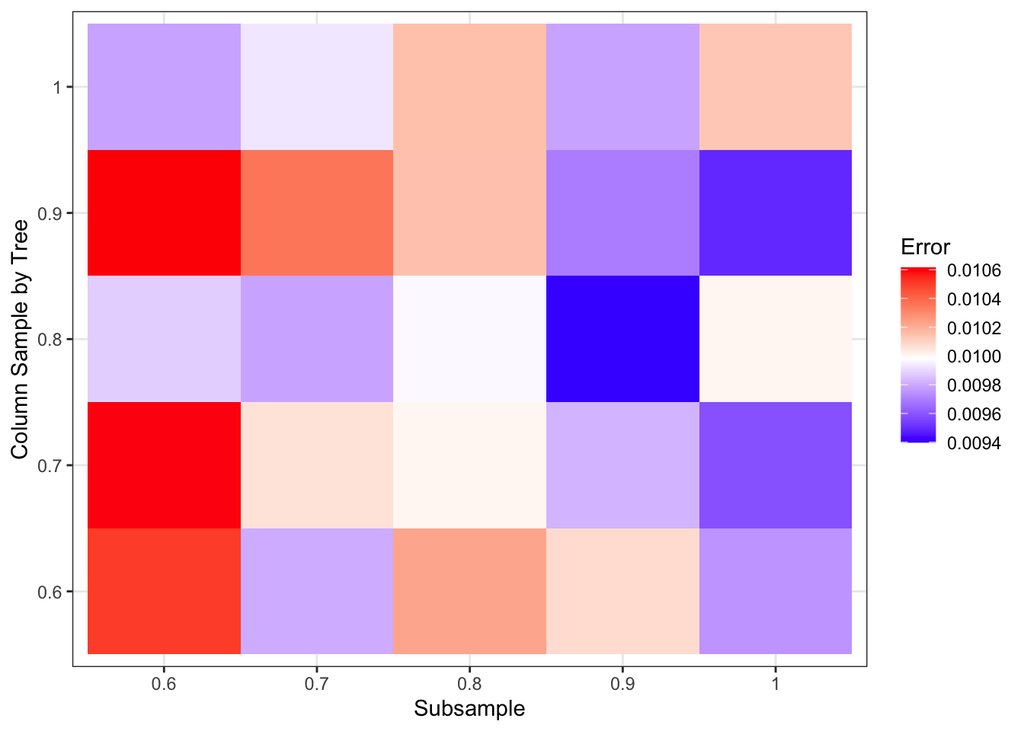

```r
g_8 <- ggplot(res_db, aes(y = colsample_by_tree, x = subsample, fill = error)) + # set aesthetics
  geom_tile() + # Use geom_tile for heatmap
  theme_bw() + # Set theme
  scale_fill_gradient2(low = "blue", # Choose low color
    mid = "white", # Choose mid color
    high = "red", # Choose high color
    midpoint =mean(res_db$error), # Choose mid point
    space = "Lab",
    na.value ="grey", # Choose NA value
    guide = "colourbar", # Set color bar
    aesthetics = "fill") + # Select aesthetics to apply
  labs(x = "Subsample", y = "Column Sample by Tree", fill = "Error") # Set labels
g_8
```

```r
# Will go with a Subsample and Column sample of 0.9
```

```r
bst_final <- xgboost(data = dtrain, # Set training data

              eta = 0.25, # Set learning rate
              max.depth =  10, # Set max depth
              min_child_weight = 5, # Set minimum number of samples in node to split
              gamma = 0.1, # Set minimum loss reduction for split
              subsample =  0.9, # Set proportion of training data to use in tree
              colsample_bytree = 0.9, # Set number of variables to use in each tree

              nrounds = 250, # Set number of rounds
              early_stopping_rounds = 20, # Set number of rounds to stop at if there is no improvement

              verbose = 1, # 1 - Prints out fit
              nthread = 1, # Set number of parallel threads
              print_every_n = 20, # Prints out result every 20th iteration

              objective = "binary:logistic", # Set objective
              eval_metric = "auc",
              eval_metric = "error") # Set evaluation metric to use
```

```
## Multiple eval metrics are present. Will use train_error for early stopping.
## Will train until train_error hasn't improved in 20 rounds.
##
## Stopping. Best iteration:
```

```r
boost_preds <- predict(bst_final, dtest) # Create predictions for XGBoost model

pred_dat <- cbind.data.frame(boost_preds , test_db$label)
# Convert predictions to classes, using optimal cut-off
boost_pred_class <- rep('nonTOR', length(boost_preds))
boost_pred_class[boost_preds >= 0.5] <- 'TOR'

t <- table(boost_pred_class, test_db$label) # Create table
confusionMatrix(t, positive = "TOR")
```

```
## Confusion Matrix and Statistics
##
##
## boost_pred_class nonTOR   TOR
##           nonTOR  11902    75
##           TOR        54  1533
##
##                Accuracy : 0.9905
##                  95% CI : (0.9887, 0.9921)
##     No Information Rate : 0.8815
##     P-Value [Acc > NIR] : < 2e-16
##
##                   Kappa : 0.9542
##
##  Mcnemar's Test P-Value : 0.07826
##
##             Sensitivity : 0.9534
##             Specificity : 0.9955
##          Pos Pred Value : 0.9660
##          Neg Pred Value : 0.9937
##              Prevalence : 0.1185
##          Detection Rate : 0.1130
##    Detection Prevalence : 0.1170
##       Balanced Accuracy : 0.9744
##
##        'Positive' Class : TOR
##
```

```r
# Seems imbalanced, scale the weights of the samples
summary(as.factor(train_db$label))
```

```
## nonTOR    TOR
##  47828   6436
```

```r
zero_weight <- 47828/6436
bst_bal <- xgboost(data = dtrain, # Set training data

              eta = 0.25, # Set learning rate
              max.depth =  10, # Set max depth
              min_child_weight = 5, # Set minimum number of samples in node to split
              gamma = 0.1, # Set minimum loss reduction for split
              subsample =  0.9, # Set proportion of training data to use in tree
              colsample_bytree = 0.9, # Set number of variables to use in each tree

              nrounds = 250, # Set number of rounds
              early_stopping_rounds = 20, # Set number of rounds to stop at if there is no improvement

              verbose = 1, # 1 - Prints out fit
              nthread = 1, # Set number of parallel threads
              print_every_n = 20, # Prints out result every 20th iteration

              scale_pos_weight = zero_weight,

              objective = "binary:logistic", # Set objective
              eval_metric = "auc",
              eval_metric = "error")
```

```
## Multiple eval metrics are present. Will use train_error for early stopping.
## Will train until train_error hasn't improved in 20 rounds.
##
## Stopping. Best iteration:
```

```r
boost_preds_bal <- predict(bst_bal, dtest) # Create predictions for XGBoost model

pred_dat <- cbind.data.frame(boost_preds_bal , test_db$label)#
# Convert predictions to classes, using optimal cut-off
boost_pred_class <- rep('nonTOR', length(boost_preds_bal))
boost_pred_class[boost_preds_bal >= 0.5] <- 'TOR'


t <- table(boost_pred_class, test_db$label) # Create table
confusionMatrix(t, positive = "TOR") # Produce confusion matrix
```

```
## Confusion Matrix and Statistics
##
##
## boost_pred_class nonTOR   TOR
##           nonTOR  11872    49
##           TOR        84  1559
##
##                Accuracy : 0.9902
##                  95% CI : (0.9884, 0.9918)
##     No Information Rate : 0.8815
##     P-Value [Acc > NIR] : < 2.2e-16
##
##                   Kappa : 0.9535
##
##  Mcnemar's Test P-Value : 0.003197
##
##             Sensitivity : 0.9695
##             Specificity : 0.9930
##          Pos Pred Value : 0.9489
##          Neg Pred Value : 0.9959
##              Prevalence : 0.1185
##          Detection Rate : 0.1149
##    Detection Prevalence : 0.1211
##       Balanced Accuracy : 0.9813
##
##        'Positive' Class : TOR
##
```

End result: Accuracy: 0.9902, Sensitivity: 0.9695, Specificity: 0.9930

3 marks for analysis decisions, modeling decisions and code readability/usability.